# Final Term Project 2022-R01 Minimizing Subway to Bus Transfer Times with Genetic Algorithm

Kwon, Donghoon

2022-06-13

# **1. Abstract**

# **2. Introduction**

## 2.1. Problem Statement

- When entering a metropolitan area, it is difficult to enter the destination by a single trip, so people usually transfer (bus-bus/train-bus)
- Good transfers, i.e. shorter transfers time, encourage citizens to use public transit, thereby increasing public transportation.
- This could lead to a reduction in the use of automobiles in metropolitan areas.
- In addition, it can increase the convenience of passengers using public transit and escalate the number of passengers using public transit.
- However, based on the Seoul metropolitan area(2015), the average transfers time for public transportation consisted of 6.3 minutes of travel time and 7 minutes of waiting time.

[figure not shown]

Fig 1. subway and bus

## 2.2. Research Objectives

- To reduce waiting time for passengers transferring from subway to bus
- To Estimate the arrival time at the passenger stop to calculate the waiting time
- Reducing waiting time for bus only users is also considered.
- To optimize bus operation time according to the distribution of arrival time of passengers obtained from card data

## 2.3. Literature Reviews

- Jansen, Leise Neel, Michael Berliner Pedersen, and Otto Anker Nielsen. “Minimizing passenger transfer times in public transport timetables.”(2002)
  - This paper presents a mathematical optimization model that can solve the problem of finding an optimal timetable for a public transport system in which waiting times connected to transfers between lines are minimized.
- Cevallos, Fabian, and Fang Zhao. “Minimizing transfer times in public transit network with genetic algorithm.” Transportation Research Record(2006)
  - This paper presents a systemwide approach based on a genetic algorithm for the optimization of bus transit system transfer times.

# **3. Data Description**

## 3.1. Description of Smart Card Data

**Table 1. Description of Smart Card Data**

| No. | Name | No.. | Name. |
| --- | --- | --- | --- |
| 1 | 일련번호 | 15 | 발권시간 |
| 2 | 가상카드번호 | 16 | 승차정류장ID_국토부표준 |
| 3 | 정산지역코드 | 17 | 승차정류장ID_교통사업자 |
| 4 | 카드구분코드 | 18 | 하차일시 |
| 5 | 차량ID_국토부표준 | 19 | 하차정류장ID_국토부표준 |
| 6 | 차량ID_정산사업자 | 20 | 하차정류장ID_정산사업자 |
| 7 | 차량등록번호 | 21 | 트랜잭션ID |
| 8 | 운행출발일시 | 22 | 환승횟수 |
| 9 | 운행종료일시 | 23 | 사용자구분코드 |
| 10 | 교통수단코드 | 24 | 이용객수_다인승 |
| 11 | 노선ID_국토부표준 | 25 | 승차금액 |
| 12 | 노선ID_정산사업자 | 26 | 하차금액 |
| 13 | 교통사업자ID | 27 | 총이용거리 |
| 14 | 승차일시 | 28 | 총탑승시간 |

## 3.2. Test Network(120 Line)

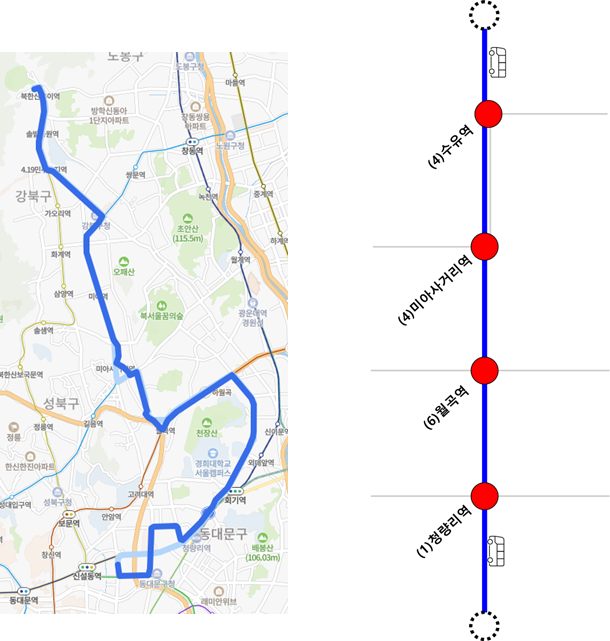

Fig 2. 120 Line Bus

- This Buses is connecting Gangbuk to Cheongnyangni in Seoul.
- Major stops are Cheongnyangni station(Line 1), Suyu Station(Line 4), Duksung Women’s University, Seoul Eastern Hospital etc..
- Before the opening of Ui-Sinseol Line, passengers who usually went to Uidong used the bus.
- In this presentation, only the peak hours of the afternoon were analyzed.

## 3.3. Data Pre-processing

### 3.3.1. Transfer Passengers

```
<pseudocode>

Data_Suyu <- filter(Data,Data$BoardingStation == "Suyu" )

ID <- unique(Data_Suyu$ID)

Data_Suyu_candidate <- filter(Data,Data$ID == ID)

Data_Transfer_Available <- filter(Data_Suyu_candidate, $Boarding == B2 & $Alighting == A1)

diff(Data_Transfer_Available$Transfer) == 1
```

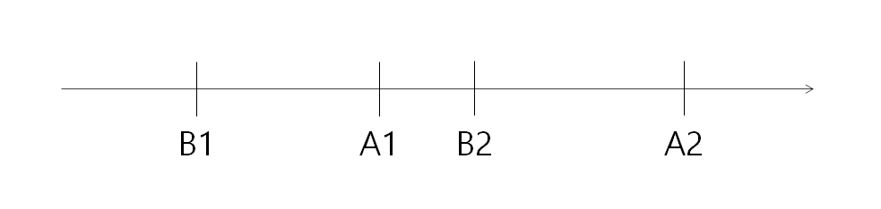

Fig 3. Transfer Time Zone

**Table 2. An example of transfer available passenger**

| ID | Boarding_Time | Boarding_Station | Alighting_Time | Alighting_Station | Transfer |
| --- | --- | --- | --- | --- | --- |
| 7nvMrOj4lTMk/lfMA+EL0glNKXjmoECEXoSvMcZl3v0= | 2017-05-17 07:21:16 | 414 | 2017-05-17 08:02:48 | 158 | 0 |
| 7nvMrOj4lTMk/lfMA+EL0glNKXjmoECEXoSvMcZl3v0= | 2017-05-17 08:35:22 | 105000447 | 2017-05-17 09:21:16 | 108000041 | 1 |

**Table 3. Trip chain of a transfer available passenger**

| Boarding_Time1 | Boarding_Station1 | Alighting_Time1 | Alighting_Station1 | Boarding_Time2 | Boarding_Station2 | Alighting_Time2 | Alighting_Station2 |
| --- | --- | --- | --- | --- | --- | --- | --- |
| 2017-05-17 07:21:16 | 414 | 2017-05-17 08:02:48 | 158 | 2017-05-17 08:35:22 | 105000447 | 2017-05-17 09:21:16 | 108000041 |

**Table 4. Transfer Ratio during the afternoon peak time**

| Bus stop NO. | Name | BoardinglSubway | Boarding | Transder ratio(%) |
| --- | --- | --- | --- | --- |
| 108000004 | 수유역.강북구청 | 190 | 337 | 56 |
| 105000447 | 청량리역환승센터 | 16 | 209 | 8 |
| 10700043 | 월곡역 | 71 | 208 | 34 |
| 108000012 | 미아사거리역 | 26 | 181 | 14 |

### 3.3.2. Bus only user

```
<pseudocode>

Data_Suyu <- filter(Data,Data$BoardingStation == "Suyu" )

BusOnlyUser <- filter(Data_Suyu, Data_Suyu$ID != Data_Transfer_Available$ID)
```

## 3.4. Assumption

### 3.4.1. Bus Timetable

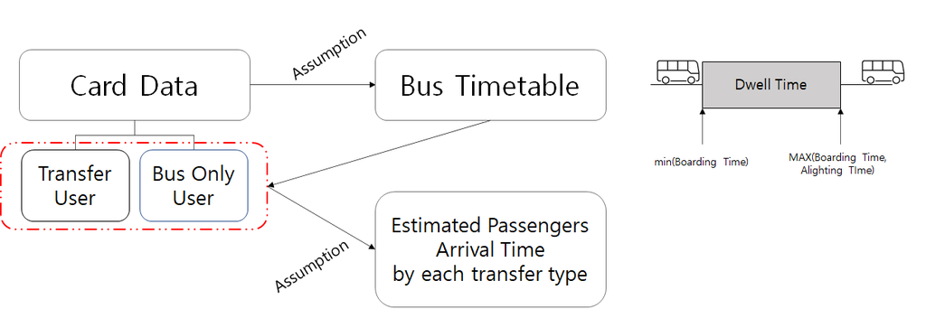

Fig 4. Framework for estimating passengers arrival time by each transfer type

### 3.4.2. Assumption

- It is supposed that the dwell time of buses follow from the first boarding time to a larger value between the last boarding time and the last alighting time

#### i) Transfer User

- It is presupposed that transfer passengers accompany a specific distribution.
- In this presentation, the fixed value is subtracted from the bus tag-in time and assumed to be the arrival time.

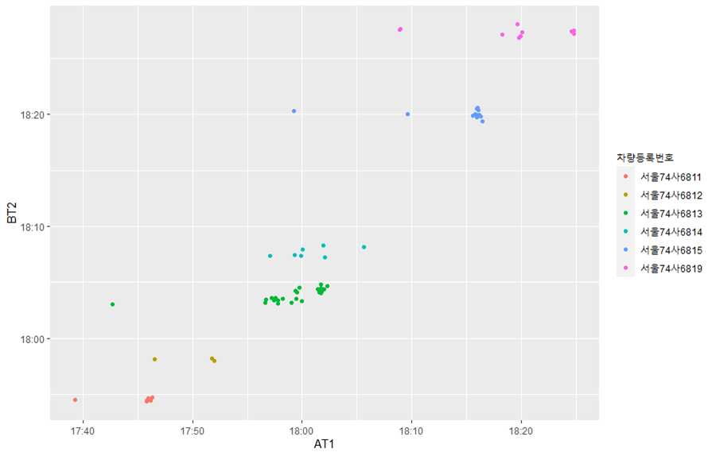

Fig 5. Distribution of transfers time

#### ii) Bus Only User

- It is assumed that the bus only users arrived at equal intervals, uniform distribution.

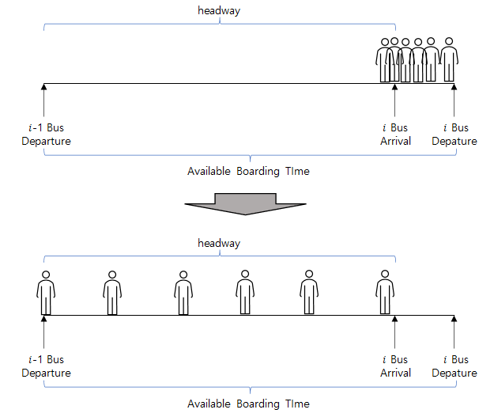

Fig 6. Uniform Distribution of bus only users

### 3.4.3 Estimating Passenger Arrival Time at the Bus Stop

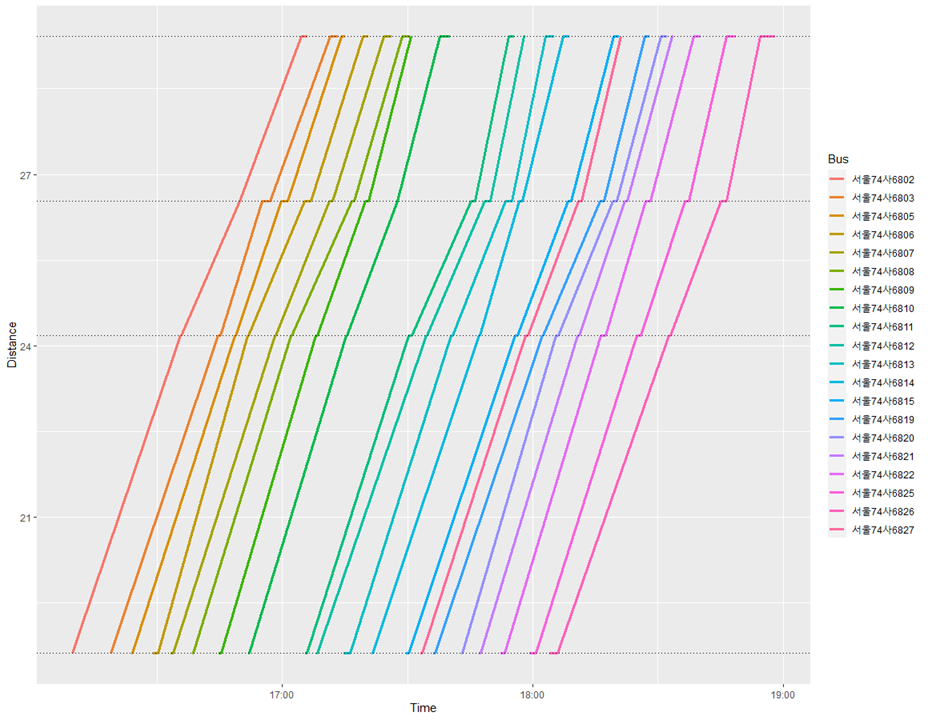

Fig 7. Bus Trajectory by data-driven

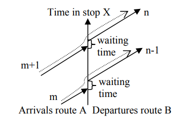

Fig 8. Passenger transfer patterns(Leise, et al., 2002)

**Table 3. Waiting time based on data-driven timetable**

[output not shown]

# **4. Methodology**

## 4.1. Genetic Algorithm

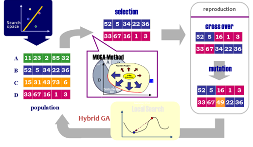

Fig 9. Genetic Algorithm

- Genetic algorithms are a family of computational models inspired by evolution. These algorithms encode a potential solution to a specific problem on a simple chromosome-like data structure, and apply recombination operators to these structures in such a way as to preserve critical information.(Darrell,1994)

## 4.2. Chromosome

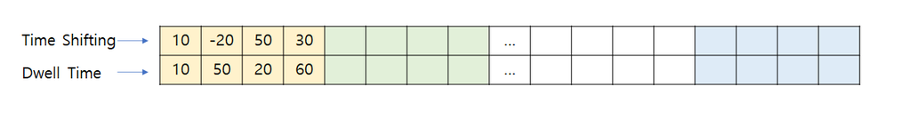

Fig 10. chromosome

- A time shifting gene indicates how fast or slow it will arrive compared to the existing timetable.
- A dwell time gene contains how long it will stop at each bus stop.

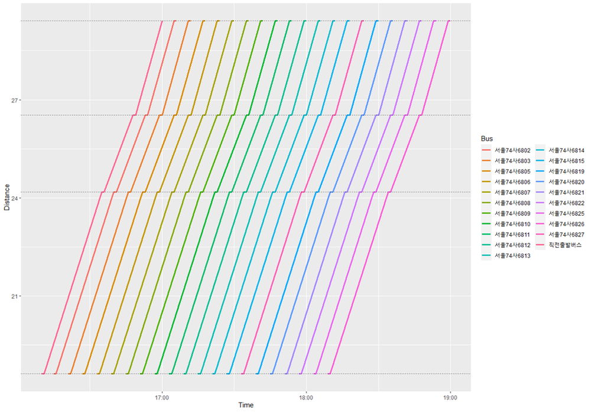

Fig 11. reference timetalbe

## 4.3. Results

**Fitness Value**

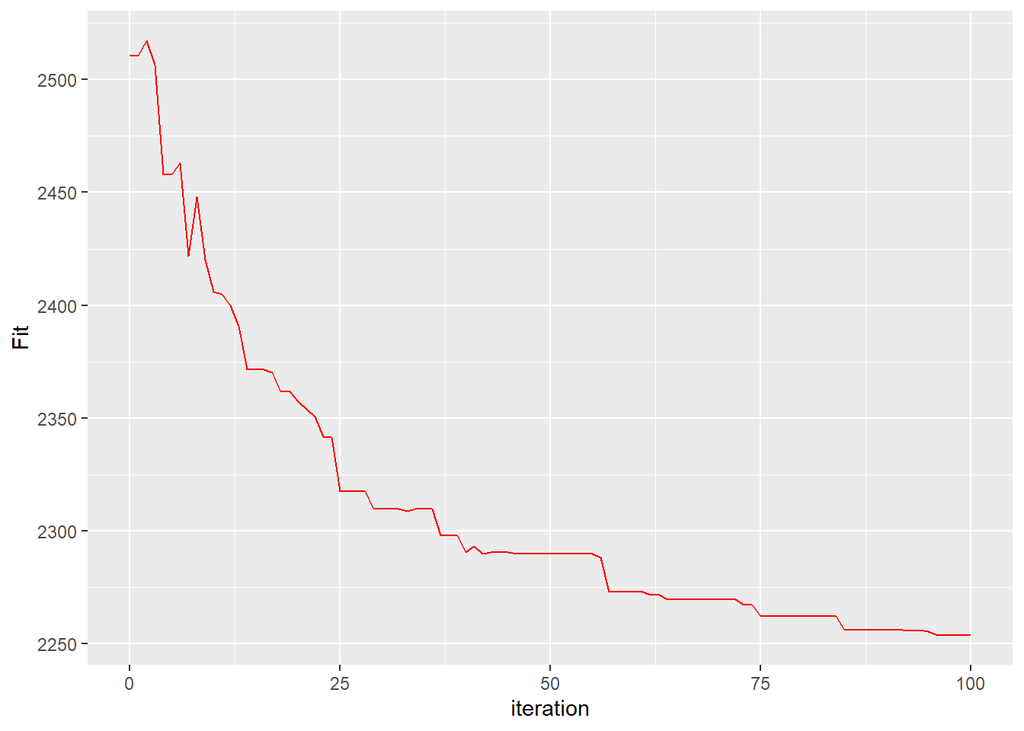

Fig 12. Fitness Value

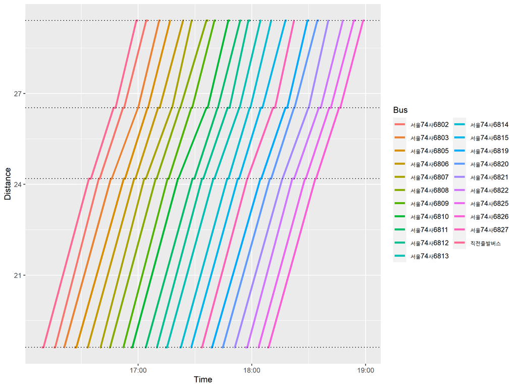

# **5. Conclusion**

- Shifting from the reference timetable seems to be effective, but more realistically, it is necessary to simulate bus movements.
- It is necessary to accurately estimate the distribution of passenger arrivals.

# References

- Jansen, Leise Neel, Michael Berliner Pedersen, and Otto Anker Nielsen. “Minimizing passenger transfer times in public transport timetables.” 7th Conference of the Hong Kong Society for Transportation Studies, Transportation in the information age, Hong Kong. 2002.
- Cevallos, Fabian, and Fang Zhao. “Minimizing transfer times in public transit network with genetic algorithm.” Transportation Research Record 1971.1 (2006): 74-79.